# Anomaly Detection - EDA Assignment II (Mortgage Default)

Ram Subramanian (RS3955)

September 22, 2019

## Exploratory Data Analysis of Loan default

#### In order to create a model for predicting loan defaults, we perform an initial data analysis on variables of our interest to see how they are correlated, followed by a detailed exploratory analysis of 15 selective variables (each commented with a reason for choosing the variable).

#### We further use variable selection methods like Stepwise Regression combined with Lasso regression to validate the significance of the variables chosen so we can come up with a Logistic model that contains the final set of variables which is a combination of both statistical as well as business significance. The accuracy of this Logistic model will be further verified by creating a Gains table at the end.

```r
#LOAD LIBRARIES AND IMPORT LOAN DEFAULT DATA

# install.packages('glmnet')
# install.packages('ROCR')
# install.packages("gains")
# install.packages('ggthemes')
# install.packages('gridExtra')
library(tidyverse)
```

```r
library(ggplot2)
library(glmnet)
library(ROCR)
library(gains)
library(ggthemes)
library(gridExtra)
library(dplyr)

setwd('C:/myfiles/Anomaly/assignment2')
loandata=read.csv('XYZloan_default_selected_vars.csv')
```

```r
str(loandata)
```

```
## 'data.frame':    80000 obs. of  89 variables:
##  $ X           : int  0 1 2 3 4 5 6 7 8 9 ...
##  $ Unnamed..0  : int  1 2 3 4 5 6 7 8 9 10 ...
##  $ id          : int  1 2 3 4 5 6 7 8 9 10 ...
##  $ loan_default: int  1 0 0 0 0 1 1 0 0 0 ...
##  $ AP001       : int  31 27 33 34 47 32 23 40 25 27 ...
##  $ AP002       : int  2 1 1 2 2 1 1 2 1 2 ...
##  $ AP003       : int  1 1 4 4 1 1 3 3 3 4 ...
##  $ AP004       : int  12 12 12 12 12 12 12 3 12 12 ...
##  $ AP005       : Factor w/ 55057 levels "2017/3/22 15:12",..: 52778 12039 46676 53398 52964 20517 21800 30539 9529 44707 ...
##  $ AP006       : Factor w/ 4 levels "android","api",..: 4 3 3 1 3 3 4 3 3 4 ...
##  $ AP007       : int  3 5 4 5 4 5 1 5 5 5 ...
##  $ AP008       : int  3 4 2 5 4 4 1 5 5 5 ...
##  $ AP009       : int  1 0 0 0 1 0 0 1 1 0 ...
##  $ TD001       : int  1 2 2 0 2 2 2 1 4 4 ...
```

[output cut: 75 more lines]

```r
ncol(loandata) #number of columns
```

```
## [1] 89
```

```r
nrow(loandata) #number of rows
```

```
## [1] 80000
```

```r
#Storing loandata in a Dataframe
df <- data.frame(loandata)
nrow(df)
```

```
## [1] 80000
```

```r
ncol(df)
```

```
## [1] 89
```

#### INITIAL CLEANSING OF DATASET

```r
#Finding columns with negative numbers
x <- stack(df); x$sign <- sign(x$values); table(x[-1])
```

```
##               sign
## ind               -1     0     1
##   X                0     1 79999
##   Unnamed..0       0     0 80000
##   id               0     0 80000
##   loan_default     0 64512 15488
##   AP001            0     0 80000
##   AP002            0     0 80000
##   AP003            0     0 80000
##   AP004            0     0 80000
##   AP007            0     0 80000
##   AP008            0     0 80000
##   AP009            0 21766 58234
##   TD001            0 19598 60402
##   TD002            0 40373 39627
##   TD005            0  7663 72337
##   TD006            0 23334 56666
##   TD009            0  3694 76306
##   TD010            0 15408 64592
##   TD013            0  2550 77450
##   TD014            0 11818 68182
##   TD015            0 40337 39663
##   TD022            0     0 60402
##   TD023            0 16409 55928
##   TD024            0 18666 57640
##   TD025            0 77450     0
##   TD026            0 78154     0
##   TD027            0 78303     0
##   TD028            0 78364     0
##   TD029            0     0 78370
##   TD044            0     0     3
##   TD048            0     0     1
##   TD051            0     0     5
##   TD054            0     0    12
##   TD055            0     0     1
##   TD061            0     0    10
##   TD062            0     0     1
##   CR004            0     0 80000
##   CR005            0     0 80000
##   CR009            0 13245 66755
```

[output cut: 33 more lines]

```
##   CD135         3307  1237 75075
##   CD136         3307  1165 75147
##   CD137         3307   156 76156
##   CD152         3307   164 76148
##   CD153         3307   220 76092
##   CD160         3307  6985 69327
##   CD162         3307  2432 73880
##   CD164         3307  4147 72165
##   CD166         3307 11087 65225
##   CD167         3307 14917 61395
##   CD169         3307  4876 71436
##   CD170         3307  7430 68882
##   CD172         3307  2674 73638
##   CD173         3307  4463 71849
##   MB005            0  1132 76075
```

```r
#Replace Negative with 0 for numeric columns

cleanFun <- function(q){

  # set negative values as 0
  q[q < 0] <- 0

  # select numeric columns
  num_cols <- names(q)[sapply(q, is.numeric)]

  return (q[num_cols])

  }

df <- cleanFun(df)
#Adding back columns with factors except the timestamp one
df<- cbind(df, data.frame(loandata[,c(10,89,drop=FALSE)]))

#Moving variables with less than 1% of valid values to the end of df and imputing their missing values with 0s
df <- df%>%select(-'TD048','TD048')
df <- df%>%select(-'TD055','TD055')
df <- df%>%select(-'TD062','TD062')

df$TD048[is.na(df$TD048)] = 0
df$TD055[is.na(df$TD055)] = 0
df$TD062[is.na(df$TD062)] = 0
```

```r
str(df)
```

```
## 'data.frame':    80000 obs. of  88 variables:
##  $ X           : int  0 1 2 3 4 5 6 7 8 9 ...
##  $ Unnamed..0  : int  1 2 3 4 5 6 7 8 9 10 ...
##  $ id          : int  1 2 3 4 5 6 7 8 9 10 ...
##  $ loan_default: int  1 0 0 0 0 1 1 0 0 0 ...
##  $ AP001       : int  31 27 33 34 47 32 23 40 25 27 ...
##  $ AP002       : int  2 1 1 2 2 1 1 2 1 2 ...
##  $ AP003       : int  1 1 4 4 1 1 3 3 3 4 ...
##  $ AP004       : int  12 12 12 12 12 12 12 3 12 12 ...
##  $ AP007       : int  3 5 4 5 4 5 1 5 5 5 ...
##  $ AP008       : int  3 4 2 5 4 4 1 5 5 5 ...
##  $ AP009       : int  1 0 0 0 1 0 0 1 1 0 ...
##  $ TD001       : int  1 2 2 0 2 2 2 1 4 4 ...
##  $ TD002       : int  1 0 1 0 0 1 0 1 1 1 ...
##  $ TD005       : int  4 3 4 0 2 5 2 1 6 6 ...
```

[output cut: 74 more lines]

```r
ncol(df)  #check the final number of columns before splitting the data
```

```
## [1] 88
```

```r
#********************************Split data into train and test sets********************************
set.seed(10000)
split = sample(1:nrow(df),size = 0.7*nrow(df))
train = df[split,]
test = df[-split,]
nrow(train)
```

```
## [1] 56000
```

```r
nrow(test)
```

```
## [1] 24000
```

```r
nrow(df)
```

```
## [1] 80000
```

```r
#************************Dealing with missing values in Train and Test data************************

sum(!!colSums(is.na(train))) #Number of Columns in Train data containing at least one NA
```

```
## [1] 55
```

```r
#Using function to list the Names of Columns in Train data containing at least one NA
contains_any_na = sapply(train, function(x) any(is.na(x)))
names(train)[contains_any_na]
```

```
##  [1] "TD022" "TD023" "TD024" "TD025" "TD026" "TD027" "TD028" "TD029"
##  [9] "TD044" "TD051" "TD054" "TD061" "PA022" "PA023" "PA028" "PA029"
## [17] "PA030" "PA031" "CD008" "CD018" "CD071" "CD072" "CD088" "CD100"
## [25] "CD101" "CD106" "CD107" "CD108" "CD113" "CD114" "CD115" "CD117"
## [33] "CD118" "CD120" "CD121" "CD123" "CD130" "CD131" "CD132" "CD133"
## [41] "CD135" "CD136" "CD137" "CD152" "CD153" "CD160" "CD162" "CD164"
## [49] "CD166" "CD167" "CD169" "CD170" "CD172" "CD173" "MB005"
```

```r
#Using function to replace NAs in Train data with the median of the respective columns
for(i in 1:(ncol(train)-5)){
  train[is.na(train[,i]), i] <- median(train[,i], na.rm = TRUE)
}
sum(!!colSums(is.na(train))) # Verifying there are no more NAs
```

```
## [1] 0
```

```r
sum(!!colSums(is.na(test))) #Number of Columns in Test data containing at least one NA
```

```
## [1] 55
```

```r
#Using function to list the Names of Columns in Test data containing at least one NA
contains_any_na = sapply(test, function(x) any(is.na(x)))
names(test)[contains_any_na]
```

```
##  [1] "TD022" "TD023" "TD024" "TD025" "TD026" "TD027" "TD028" "TD029"
##  [9] "TD044" "TD051" "TD054" "TD061" "PA022" "PA023" "PA028" "PA029"
## [17] "PA030" "PA031" "CD008" "CD018" "CD071" "CD072" "CD088" "CD100"
## [25] "CD101" "CD106" "CD107" "CD108" "CD113" "CD114" "CD115" "CD117"
## [33] "CD118" "CD120" "CD121" "CD123" "CD130" "CD131" "CD132" "CD133"
## [41] "CD135" "CD136" "CD137" "CD152" "CD153" "CD160" "CD162" "CD164"
## [49] "CD166" "CD167" "CD169" "CD170" "CD172" "CD173" "MB005"
```

```r
#Using function to replace NAs in Test data with the median of the respective columns
for(i in 1:(ncol(test)-5)){
  test[is.na(test[,i]), i] <- median(test[,i], na.rm = TRUE)
}
sum(!!colSums(is.na(test))) # Verifying there are no more NAs
```

```
## [1] 1
```

### Initial Exploratory Data Analysis

```r
#Examine correlations between loan_default and some primary variables of interest in Train data
cor(train$loan_default, train$AP001) #Age:
```

```
## [1] -0.02478795
```

```r
cor(train$loan_default, train$AP003) #Education
```

```
## [1] -0.08483444
```

```r
cor(train$loan_default, train$AP004) #Loan term
```

```
## [1] 0.0975438
```

```r
cor(train$loan_default, train$AP007) #Applying City
```

```
## [1] 0.03856197
```

```r
cor(train$loan_default, train$CR009) #Total loan amount
```

```
## [1] -0.02489878
```

```r
cor(train$loan_default, train$CR017) #Debit card score_total
```

```
## [1] -0.04814849
```

```r
cor(train$loan_default, train$CR018) #Debit card score_utility
```

```
## [1] -0.03425758
```

### Exploratory Data Analysis of selective variables

```r
#Function to compute the frequency of variable and store it in a dataframe

getfreq <- function(data, col_name){
  data %>%
    group_by_(col_name) %>%
    summarise(X_counts = n(),
              Y_counts = sum(loan_default)) %>%
    mutate(   Y_by_X_pcnt = Y_counts/X_counts,
              X_pcnt = X_counts/sum(X_counts))
}
```

```r
#Function to generate one-way frequency bar chart

one_two_way_plot <-function(df1,var){

  theme_set(theme_bw())

  # Draw plot
  p1 <- ggplot(df1, aes(x=get(var), y=X_pcnt, fill=get(var))) +
    geom_bar(stat="identity", width=0.8) +
    labs(title="One-way frequency barchart",
         subtitle=var,
         caption="source: data") +
    coord_cartesian(ylim=c(0,1)) +
    theme(axis.text.x = element_text(angle=65, vjust=0.6))

  # Draw plot
  p2 <- ggplot(df1, aes(x=get(var), y=Y_by_X_pcnt, fill=get(var))) +
    geom_bar(stat="identity", width=0.8) +
    labs(title="% of Y by X",
         subtitle=var,
         caption="source: data") +
    coord_cartesian(ylim=c(0,1)) +
    theme(axis.text.x = element_text(angle=65, vjust=0.6))

  require(gridExtra)
  grid.arrange(p1, p2, nrow=2,heights=c(1, 1))
}
```

#### 1. Analysis of AP003 (Education)

```r
df3 <- getfreq(train,"AP003")
df3
```

```
## # A tibble: 5 x 5
##   AP003 X_counts Y_counts Y_by_X_pcnt   X_pcnt
##   <int>    <int>    <int>       <dbl>    <dbl>
## 1     1    31563     7003      0.222  0.564
## 2     3    16709     2895      0.173  0.298
## 3     4     7547      991      0.131  0.135
## 4     5      173       10      0.0578 0.00309
## 5     6        8        0      0      0.000143
```

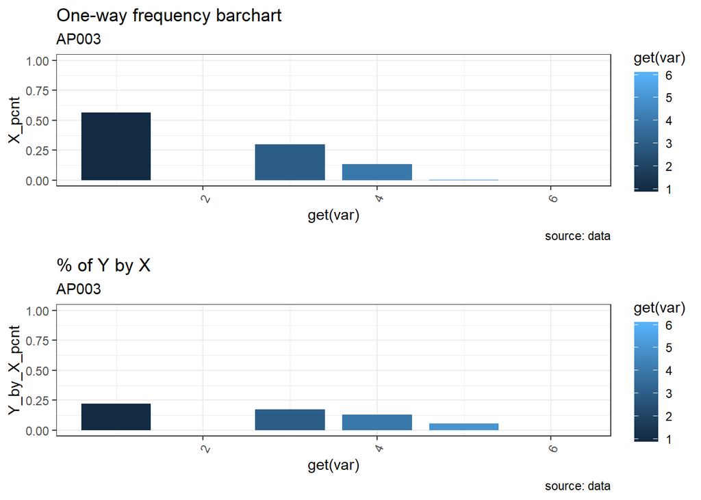

```r
one_two_way_plot(df3,"AP003")
```

##### Our inital correlation analysis implied that education had one of the strongest correlation with Loan default and the plot reflects the same. Higher the education lower is the risk of default.

#### 2. Analysis of AP004 (Loan term)

```r
df4 <- getfreq(train,"AP004")
df4
```

```
## # A tibble: 4 x 5
##   AP004 X_counts Y_counts Y_by_X_pcnt X_pcnt
##   <int>    <int>    <int>       <dbl>  <dbl>
## 1     3     2365      108      0.0457 0.0422
## 2     6     2700      274      0.101  0.0482
## 3     9     1585      282      0.178  0.0283
## 4    12    49350    10235      0.207  0.881
```

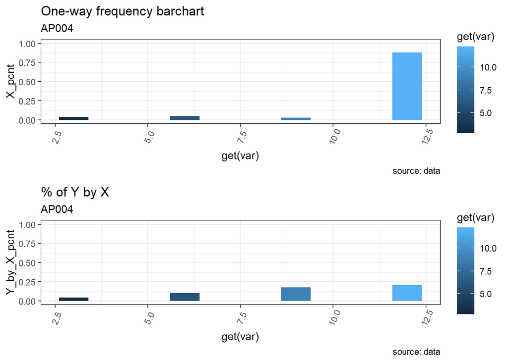

```r
one_two_way_plot(df4,"AP004")
```

##### Also reflective of our initial correlation analysis, loan term being a variable with a very high positive correlation with Loan default, the plot shows the highest incidents of loan term are concentrated highly on the longest loan terms

#### 3. Analysis of PA023 (Days b/w application & 1st collection call)

```r
df23 <- getfreq(train,"PA023")
df23
```

```
## # A tibble: 159 x 5
##    PA023 X_counts Y_counts Y_by_X_pcnt  X_pcnt
##    <dbl>    <int>    <int>       <dbl>   <dbl>
##  1     0    40620     7147       0.176 0.725
##  2     1      118       33       0.280 0.00211
##  3     2      108       27       0.25  0.00193
##  4     3      101       22       0.218 0.00180
##  5     4       89       14       0.157 0.00159
##  6     5       99       22       0.222 0.00177
##  7     6      103       26       0.252 0.00184
##  8     7      103       21       0.204 0.00184
##  9     8      102       26       0.255 0.00182
## 10     9       86       21       0.244 0.00154
## # ... with 149 more rows
```

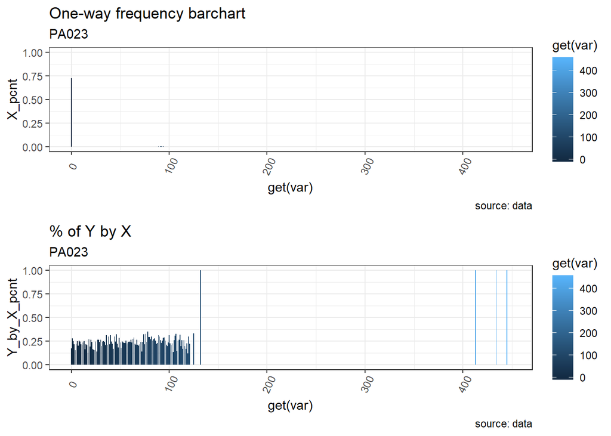

```r
one_two_way_plot(df23,"PA023")
```

##### The plot shows some peak values on the higher side of the number of days between loan application and first collection call. The first collection call is usually made when the loanee has prolonged his loan payment for a long time.Such loanees could fall under higher probability of defaulters

#### 4. Analysis of AP008 (Level IP City)

```r
df8 <- getfreq(train,"AP008")
df8
```

```
## # A tibble: 5 x 5
##   AP008 X_counts Y_counts Y_by_X_pcnt X_pcnt
##   <int>    <int>    <int>       <dbl>  <dbl>
## 1     1     5879      993       0.169  0.105
## 2     2    15245     2744       0.180  0.272
## 3     3    12965     2550       0.197  0.232
## 4     4     9981     2121       0.213  0.178
## 5     5    11930     2491       0.209  0.213
```

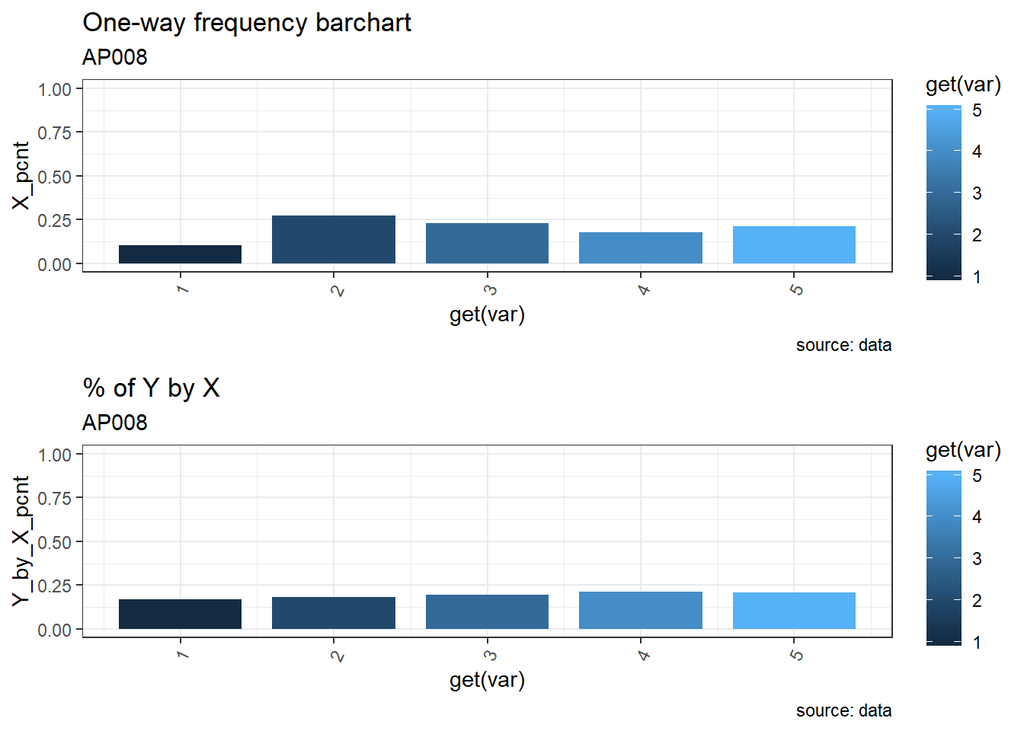

```r
one_two_way_plot(df8,"AP008")
```

##### The variable related to city was chosen to see if it had some relation to the loan default. By looking at the plot IP City variable does not seem to have major relationship with loan default though it shows some variations. So, we would leave to the variable selction methods to decide if it needs to be part of the final model.

#### 5. Analysis of AP006 (OS type)

```r
df6 <- getfreq(train,"AP006")
df6
```

```
## # A tibble: 4 x 5
##   AP006   X_counts Y_counts Y_by_X_pcnt X_pcnt
##   <fct>      <int>    <int>       <dbl>  <dbl>
## 1 android    11919     2655       0.223 0.213
## 2 api         1006      190       0.189 0.0180
## 3 h5         30947     5821       0.188 0.553
## 4 ios        12128     2233       0.184 0.217
```

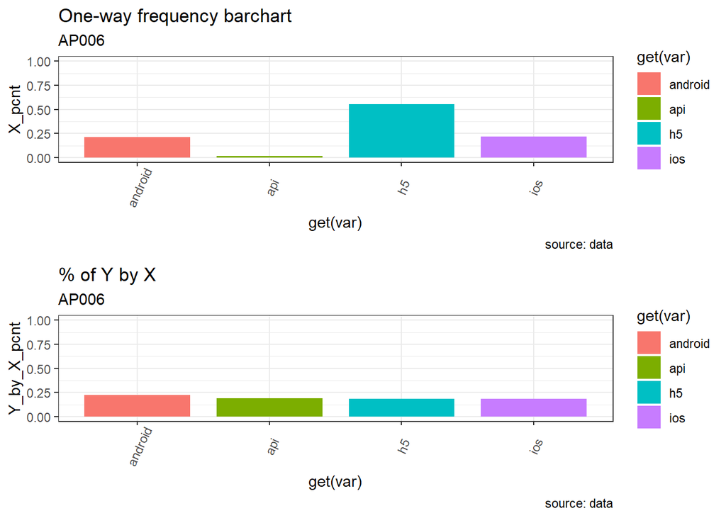

```r
one_two_way_plot(df6,"AP006")
```

#### 6. Analysis of CR018 (Score debit card utility amt)

```r
df18 <- getfreq(train,"CR018")
df18
```

```
## # A tibble: 9 x 5
##   CR018 X_counts Y_counts Y_by_X_pcnt X_pcnt
##   <int>    <int>    <int>       <dbl>  <dbl>
## 1     0     2145      404       0.188 0.0383
## 2     1     5520     1164       0.211 0.0986
## 3     2     8990     1883       0.209 0.161
## 4     3     7485     1532       0.205 0.134
## 5     4     5984     1226       0.205 0.107
## 6     5     4971     1001       0.201 0.0888
## 7     6     3852      742       0.193 0.0688
## 8     7     9120     1644       0.180 0.163
## 9     8     7933     1303       0.164 0.142
```

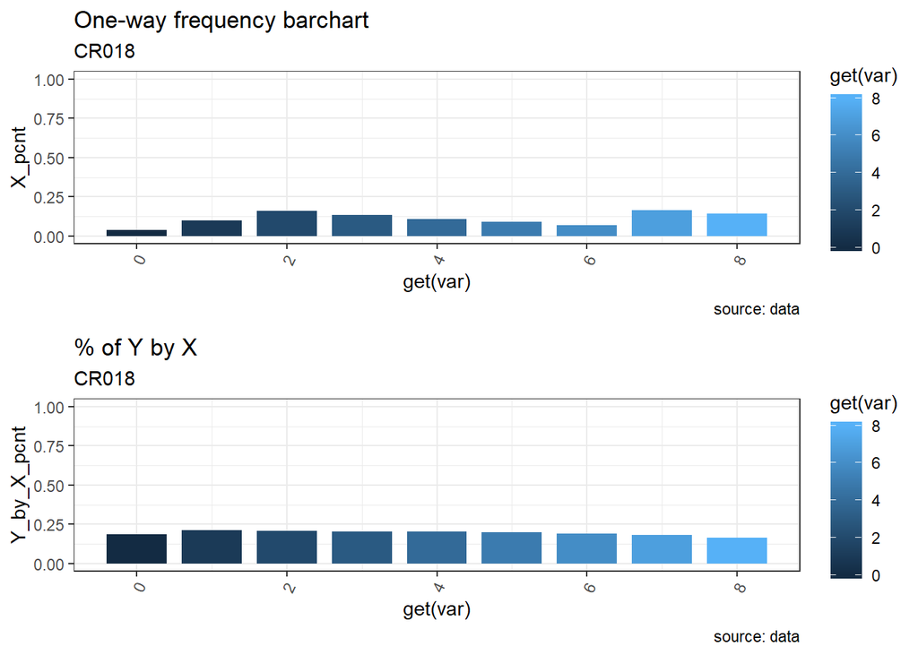

```r
one_two_way_plot(df18,"CR018")
```

##### Utility debit card score is expected to be a very important attribute influencing the loan default as it takes into account factors similar to a FICO score which is an established variable in determining mortgage defaults in the industry. We do see some variations in the plot which can be further analyzed using statistical feature selection methods.

#### 7. Analysis of CR017 (Score debit card total amt)

```r
df17 <- getfreq(train,"CR017")
df17
```

```
## # A tibble: 8 x 5
##   CR017 X_counts Y_counts Y_by_X_pcnt X_pcnt
##   <int>    <int>    <int>       <dbl>  <dbl>
## 1     1     3193      705       0.221 0.0570
## 2     2     7387     1624       0.220 0.132
## 3     3     6620     1432       0.216 0.118
## 4     4     5562     1147       0.206 0.0993
## 5     5     4649      892       0.192 0.0830
## 6     6     3955      767       0.194 0.0706
## 7     7    10118     1891       0.187 0.181
## 8     8    14516     2441       0.168 0.259
```

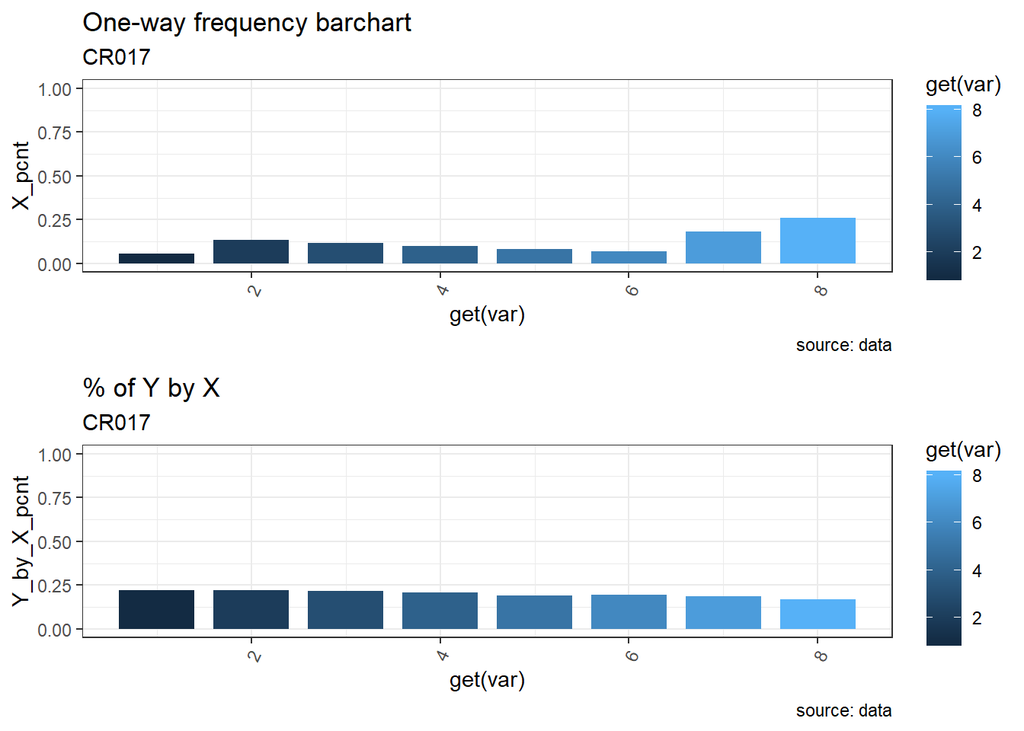

```r
one_two_way_plot(df17,"CR017")
```

##### Total debit card score is also expected to be a very important attribute influencing the loan default as it takes into account factors similar to a FICO score which is an established variable in determining mortgage defaults in the industry. We do see some variations in the plot which can be further analyzed using statistical feature selection methods.

#### 8. Analysis of AP007 (Level Application City)

```r
df7 <- getfreq(train,"AP007")
df7
```

```
## # A tibble: 5 x 5
##   AP007 X_counts Y_counts Y_by_X_pcnt X_pcnt
##   <int>    <int>    <int>       <dbl>  <dbl>
## 1     1     5909      993       0.168  0.106
## 2     2    11750     2056       0.175  0.210
## 3     3    12338     2383       0.193  0.220
## 4     4    11302     2413       0.214  0.202
## 5     5    14701     3054       0.208  0.263
```

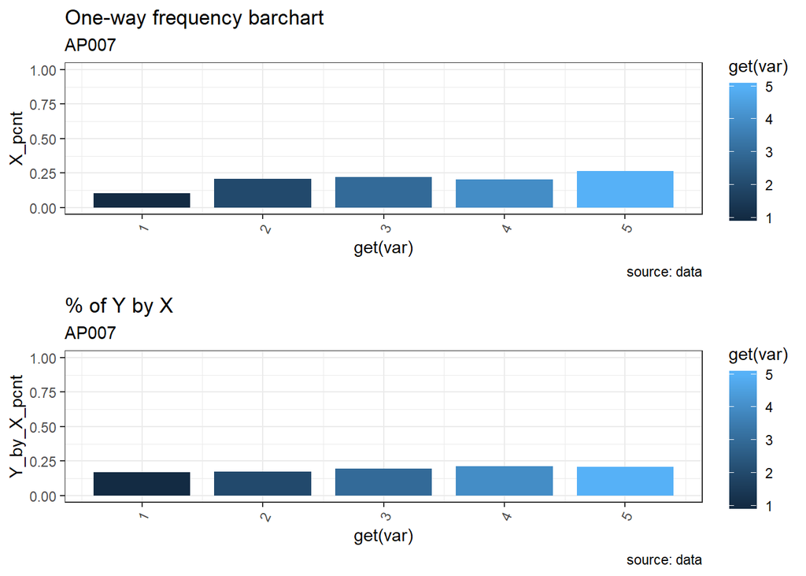

```r
one_two_way_plot(df7,"AP007")
```

##### The variable Application city was chosen to see if it had some relation to the loan default based on the city loan is applied. By looking at the plot App City variable does not seem to have major relationship with loan default though it shows some variation. So, we would leave to the variable selction methods to decide if it needs to be part of the final model.

#### 9. Analysis of PA022 (Days b/w application & High risk 1st collection call)

```r
df22 <- getfreq(train,"PA022")
df22
```

```
## # A tibble: 164 x 5
##    PA022 X_counts Y_counts Y_by_X_pcnt  X_pcnt
##    <dbl>    <int>    <int>       <dbl>   <dbl>
##  1     0    36856     6325       0.172 0.658
##  2     1      141       44       0.312 0.00252
##  3     2      143       29       0.203 0.00255
##  4     3      120       26       0.217 0.00214
##  5     4      105       17       0.162 0.00188
##  6     5      117       28       0.239 0.00209
##  7     6      135       37       0.274 0.00241
##  8     7      118       29       0.246 0.00211
##  9     8      121       29       0.240 0.00216
## 10     9      116       30       0.259 0.00207
## # ... with 154 more rows
```

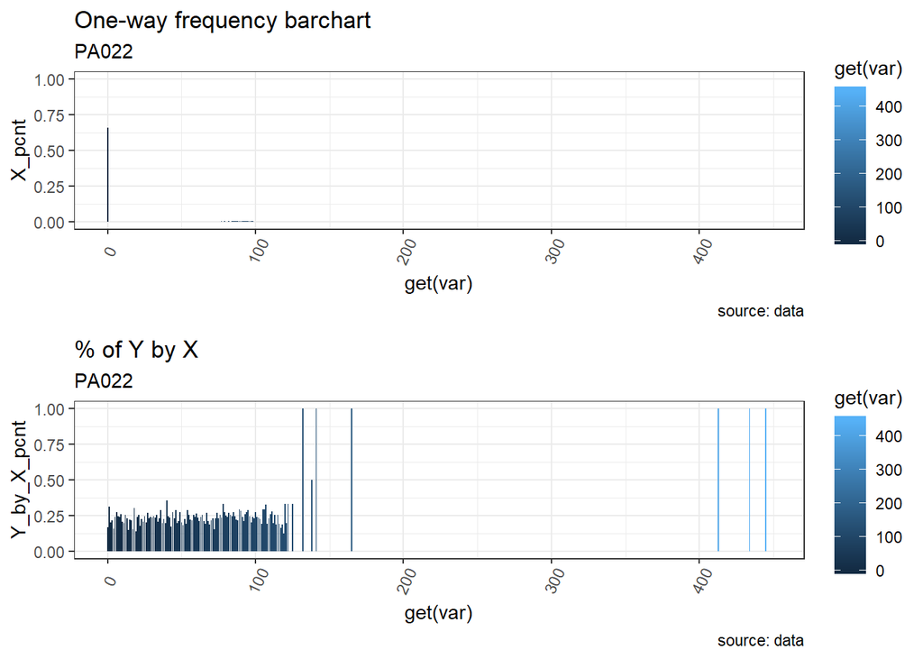

```r
one_two_way_plot(df22,"PA022")
```

##### The High risk collection call is usually made when the loanee has prolonged his loan payment for a long time. Such loanees could fall under higher probability of defaulters. The plot shows some significant peaks on the higher side of the number of days between loan application and high risk collection call as expected. This could possibly be a significant variable.

#### 10. Analysis of AP001 (Age)

```r
df01 <- getfreq(train,"AP001")
df01
```

```
## # A tibble: 37 x 5
##    AP001 X_counts Y_counts Y_by_X_pcnt  X_pcnt
##    <int>    <int>    <int>       <dbl>   <dbl>
##  1    20       78       15       0.192 0.00139
##  2    21      434      109       0.251 0.00775
##  3    22     1128      226       0.200 0.0201
##  4    23     2051      407       0.198 0.0366
##  5    24     3070      613       0.200 0.0548
##  6    25     3397      696       0.205 0.0607
##  7    26     3802      763       0.201 0.0679
##  8    27     4359      953       0.219 0.0778
##  9    28     4174      859       0.206 0.0745
## 10    29     3569      705       0.198 0.0637
## # ... with 27 more rows
```

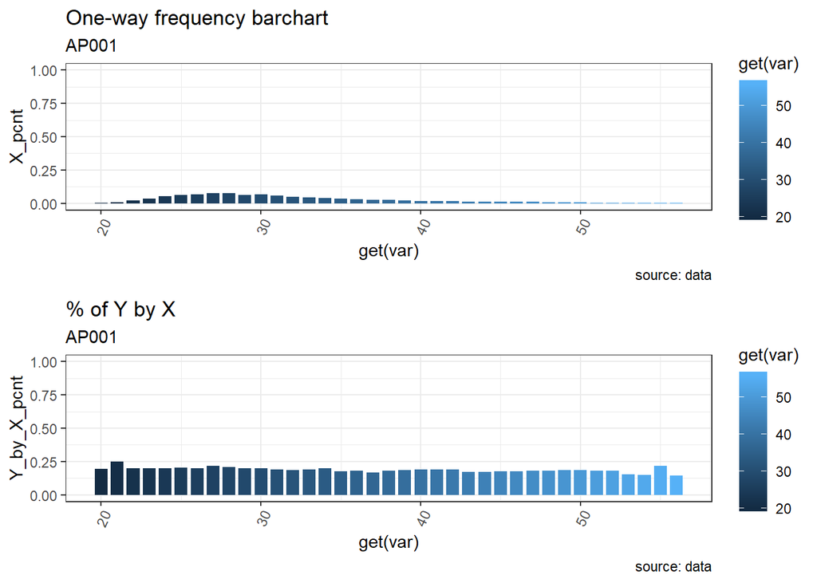

```r
one_two_way_plot(df01,"AP001")
```

##### There is a general stigma that people on the higher side of age may not have the capacity to repay loans. However, our initial correlation analysis showed that age was not among the variables with high correlation with loan defaults. The plot shows a slightly high frequency at the late 20s number but we will need further feature selection analysis to check if Age considered to be a significant variable.

#### 11. Analysis of CD160 (Count of Service calls_last 2 months)

```r
df160 <- getfreq(train,"CD160")
df160
```

```
## # A tibble: 232 x 5
##    CD160 X_counts Y_counts Y_by_X_pcnt X_pcnt
##    <dbl>    <int>    <int>       <dbl>  <dbl>
##  1     0     7198     1203       0.167 0.129
##  2     1     3837      677       0.176 0.0685
##  3     2     3678      690       0.188 0.0657
##  4     3     3530      658       0.186 0.0630
##  5     4     3346      567       0.169 0.0598
##  6     5     3021      563       0.186 0.0539
##  7     6     2815      520       0.185 0.0503
##  8     7     2922      591       0.202 0.0522
##  9     8     2330      455       0.195 0.0416
## 10     9     2143      409       0.191 0.0383
## # ... with 222 more rows
```

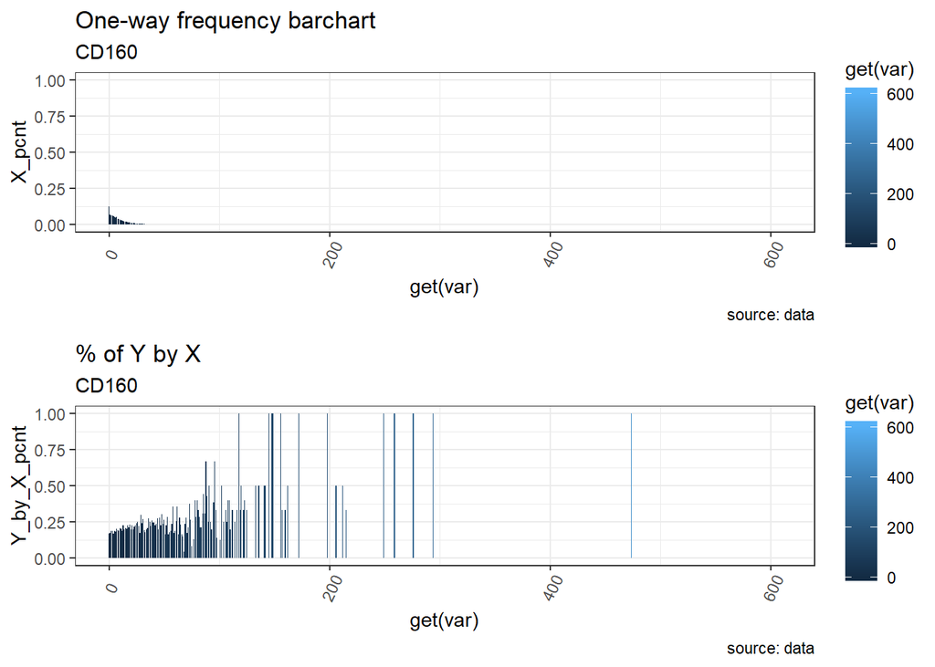

```r
one_two_way_plot(df160,"CD160")
```

##### The count of service calls in the last 2 months was chosen to see if there are any significant relation with the loan default and the plot seems to convey that the occurence of defaults are more likely when the values go higher than 100.

#### 12. Analysis of CD162 (Count of Service calls_last 3 months)

```r
df162 <- getfreq(train,"CD162")
df162
```

```
## # A tibble: 331 x 5
##    CD162 X_counts Y_counts Y_by_X_pcnt X_pcnt
##    <dbl>    <int>    <int>       <dbl>  <dbl>
##  1     0     4017      700       0.174 0.0717
##  2     1     1805      297       0.165 0.0322
##  3     2     2036      348       0.171 0.0364
##  4     3     2271      415       0.183 0.0406
##  5     4     2278      383       0.168 0.0407
##  6     5     2248      403       0.179 0.0401
##  7     6     2180      396       0.182 0.0389
##  8     7     2197      383       0.174 0.0392
##  9     8     2148      373       0.174 0.0384
## 10     9     2054      384       0.187 0.0367
## # ... with 321 more rows
```

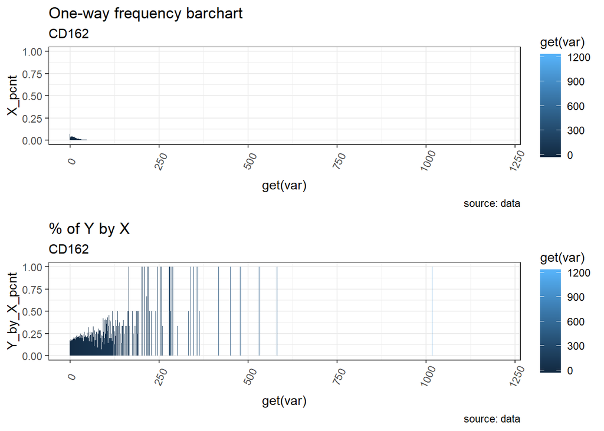

```r
one_two_way_plot(df162,"CD162")
```

##### Similarly, the occurences of loan default seem to increase with the increase in count of service calls in the last 3 months.

#### 13. Analysis of CD164 (Count of Service outbound calls_last 3 months)

```r
df164 <- getfreq(train,"CD164")
df164
```

```
## # A tibble: 283 x 5
##    CD164 X_counts Y_counts Y_by_X_pcnt X_pcnt
##    <dbl>    <int>    <int>       <dbl>  <dbl>
##  1     0     5210      893       0.171 0.0930
##  2     1     2500      397       0.159 0.0446
##  3     2     2618      450       0.172 0.0468
##  4     3     2668      498       0.187 0.0476
##  5     4     2575      452       0.176 0.0460
##  6     5     2492      456       0.183 0.0445
##  7     6     2363      409       0.173 0.0422
##  8     7     2347      405       0.173 0.0419
##  9     8     2172      403       0.186 0.0388
## 10     9     2070      418       0.202 0.0370
## # ... with 273 more rows
```

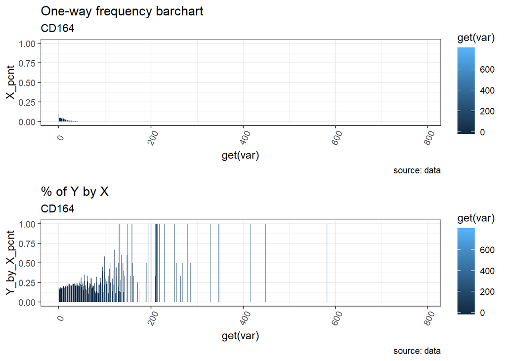

```r
one_two_way_plot(df164,"CD164")
```

##### Also, the occurences of loan default seem to increase with the increase in count of service outbound calls in the last 3 months

#### 14. Analysis of TD006 (Count of Small loan queries_last 1 month)

```r
df006 <- getfreq(train,"TD006")
df006
```

```
## # A tibble: 21 x 5
##    TD006 X_counts Y_counts Y_by_X_pcnt  X_pcnt
##    <int>    <int>    <int>       <dbl>   <dbl>
##  1     0    16297     2765       0.170 0.291
##  2     1    20342     3630       0.178 0.363
##  3     2    10838     2255       0.208 0.194
##  4     3     4731     1155       0.244 0.0845
##  5     4     1967      524       0.266 0.0351
##  6     5      888      255       0.287 0.0159
##  7     6      442      147       0.333 0.00789
##  8     7      201       58       0.289 0.00359
##  9     8      106       36       0.340 0.00189
## 10     9       73       32       0.438 0.00130
## # ... with 11 more rows
```

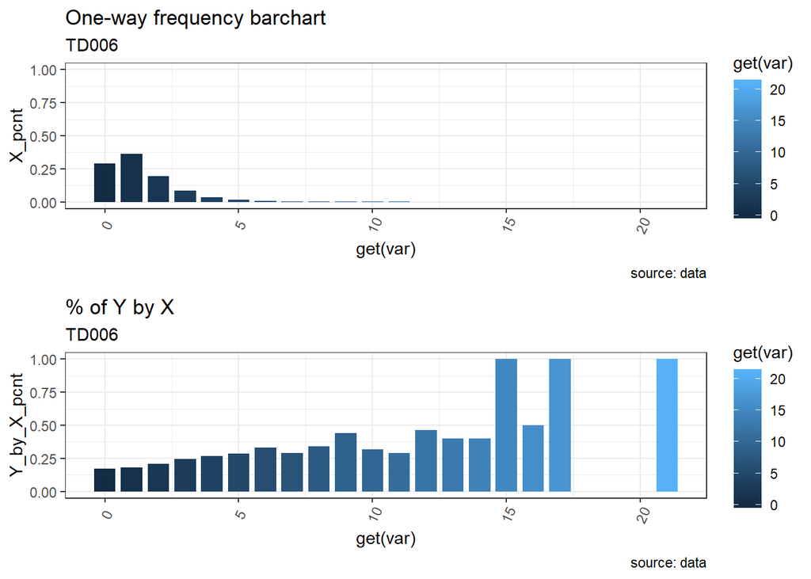

```r
one_two_way_plot(df006,"TD006")
```

#### 15. Analysis of TD010 (Count of Small loan queries_last 3 months)

```r
df010 <- getfreq(train,"TD010")
df010
```

```
## # A tibble: 29 x 5
##    TD010 X_counts Y_counts Y_by_X_pcnt  X_pcnt
##    <int>    <int>    <int>       <dbl>   <dbl>
##  1     0    10708     1656       0.155 0.191
##  2     1    16434     2729       0.166 0.293
##  3     2    12214     2351       0.192 0.218
##  4     3     7374     1635       0.222 0.132
##  5     4     4075     1013       0.249 0.0728
##  6     5     2256      618       0.274 0.0403
##  7     6     1258      349       0.277 0.0225
##  8     7      663      199       0.300 0.0118
##  9     8      360      105       0.292 0.00643
## 10     9      205       73       0.356 0.00366
## # ... with 19 more rows
```

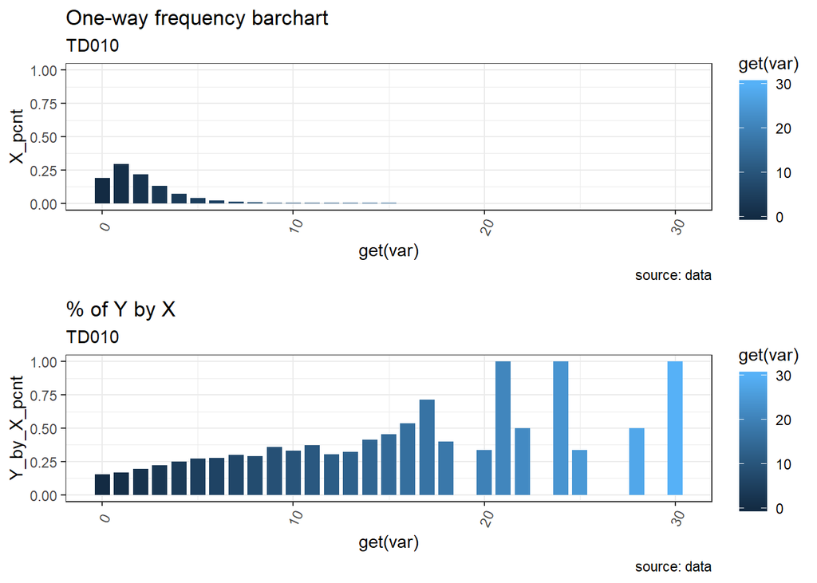

```r
one_two_way_plot(df010,"TD010")
```

##### The last 2 variables, TD006 and TD010 were analyzed to see if the number of small loan queries in the last 1-3 months is related to the default trend as people may tend to query on more number of smaller loans to pay the interests for their existing loans. The plot seems to suggest that % of defaults per count of small loan queries in the last 1-3 months seems to be high at the higher range.

### FEATURE SELECTION

```r
#Forward Stepwise variable selection
start_mod = lm(loan_default~1,data=train)
empty_mod = lm(loan_default~1,data=train)
full_mod = lm(loan_default~.,data=train)
forwardStepwise = step(start_mod,scope=list(upper=full_mod,lower=empty_mod),direction='forward')
```

```
## Start:  AIC=-103773.2
## loan_default ~ 1
##
##              Df Sum of Sq    RSS     AIC
## + TD013       1   169.803 8608.0 -104865
## + TD009       1   160.442 8617.3 -104804
## + TD005       1   132.829 8645.0 -104625
## + TD014       1   113.049 8664.7 -104497
## + TD010       1    99.954 8677.8 -104413
## + AP004       1    83.519 8694.3 -104307
## + TD023       1    74.139 8703.6 -104246
## + TD024       1    70.151 8707.6 -104221
## + TD001       1    66.245 8711.5 -104195
## + TD006       1    63.198 8714.6 -104176
## + AP003       1    63.173 8714.6 -104176
## + PA022       1    46.535 8731.2 -104069
## + PA023       1    45.408 8732.4 -104062
## + TD022       1    42.984 8734.8 -104046
## + MB005       1    40.695 8737.1 -104031
## + PA029       1    31.582 8746.2 -103973
## + PA028       1    29.757 8748.0 -103961
## + TD015       1    27.742 8750.0 -103948
## + CR015       1    26.324 8751.5 -103939
## + PA031       1    25.718 8752.1 -103935
## + TD002       1    24.119 8753.7 -103925
## + CD120       1    23.715 8754.1 -103923
## + CD123       1    23.703 8754.1 -103923
## + CD117       1    23.693 8754.1 -103923
## + CR019       1    21.730 8756.1 -103910
## + CR017       1    20.349 8757.4 -103901
## + CR004       1    17.718 8760.1 -103884
## + CD115       1    15.637 8762.1 -103871
## + CD118       1    14.391 8763.4 -103863
## + CD121       1    13.625 8764.2 -103858
## + AP007       1    13.053 8764.7 -103854
## + AP002       1    11.605 8766.2 -103845
## + AP006       3    12.122 8765.7 -103845
## + AP008       1    11.358 8766.4 -103844
## + CR018       1    10.301 8767.5 -103837
## + CD173       1     9.963 8767.8 -103835
```

[output cut: 2334 more lines]

```
## + TD023       1    0.0110 8165.1 -107749
## + CD160       1    0.0109 8165.1 -107749
## + CR019       1    0.0100 8165.1 -107749
## + CD120       1    0.0059 8165.1 -107749
## + PA031       1    0.0038 8165.1 -107749
## + CD088       1    0.0035 8165.1 -107749
## + CD118       1    0.0019 8165.1 -107749
## + CD135       1    0.0014 8165.1 -107749
## + CD018       1    0.0014 8165.1 -107749
## + CD164       1    0.0014 8165.1 -107749
## + TD014       1    0.0001 8165.1 -107749
## + CD101       1    0.0001 8165.1 -107749
## + CD172       1    0.0001 8165.1 -107749
## + CD166       1    0.0000 8165.1 -107749
## + MB007      97   19.4698 8145.6 -107691
```

```r
summary(forwardStepwise)
```

```
##
## Call:
## lm(formula = loan_default ~ TD013 + AP004 + AP003 + MB005 + PA023 +
##     CD123 + TD005 + AP002 + AP006 + CR015 + CD170 + CD113 + AP007 +
##     PA029 + CD107 + CR004 + TD010 + CD137 + CD133 + CR018 + TD001 +
##     AP009 + AP008 + CD121 + CR017 + CR005 + CD132 + CD117 + CD008 +
##     CD153 + PA022 + CD071 + CD152 + CD106 + CD108, data = train)
##
## Residuals:
##      Min       1Q   Median       3Q      Max
## -0.80025 -0.22908 -0.15471 -0.02942  1.22101
##
## Coefficients:
##               Estimate Std. Error t value Pr(>|t|)
## (Intercept)  1.161e-01  1.490e-02   7.794 6.60e-15 ***
## TD013        6.905e-03  5.264e-04  13.116  < 2e-16 ***
## AP004        2.021e-02  7.403e-04  27.297  < 2e-16 ***
## AP003       -4.046e-02  1.459e-03 -27.738  < 2e-16 ***
## MB005       -6.374e-03  4.805e-04 -13.265  < 2e-16 ***
## PA023        3.858e-04  1.036e-04   3.725 0.000196 ***
## CD123       -2.549e-04  8.361e-05  -3.048 0.002303 **
## TD005        5.600e-03  1.114e-03   5.029 4.94e-07 ***
## AP002       -3.546e-02  3.589e-03  -9.881  < 2e-16 ***
## AP006api    -6.570e-02  1.262e-02  -5.207 1.92e-07 ***
## AP006h5     -3.676e-02  4.216e-03  -8.721  < 2e-16 ***
## AP006ios    -3.984e-02  5.009e-03  -7.954 1.84e-15 ***
## CR015       -1.617e-02  1.639e-03  -9.865  < 2e-16 ***
## CD170        6.853e-06  7.994e-07   8.572  < 2e-16 ***
## CD113        3.928e-03  3.726e-04  10.541  < 2e-16 ***
## AP007        3.507e-03  1.976e-03   1.774 0.075999 .
## PA029        1.687e-04  2.928e-05   5.760 8.44e-09 ***
## CD107       -8.175e-03  3.610e-03  -2.265 0.023535 *
## CR004        6.070e-03  1.747e-03   3.474 0.000513 ***
## TD010        5.319e-03  1.115e-03   4.772 1.83e-06 ***
## CD137       -2.526e-04  6.332e-05  -3.990 6.62e-05 ***
## CD133        1.169e-04  3.461e-05   3.379 0.000729 ***
## CR018        6.412e-03  1.344e-03   4.770 1.85e-06 ***
## TD001        4.694e-03  1.273e-03   3.687 0.000228 ***
## AP009       -1.603e-02  3.860e-03  -4.153 3.29e-05 ***
## AP008        7.444e-03  1.951e-03   3.816 0.000136 ***
## CD121        1.194e-04  4.217e-05   2.832 0.004633 **
## CR017       -4.662e-03  1.418e-03  -3.287 0.001012 **
## CR005        5.503e-03  1.805e-03   3.049 0.002295 **
## CD132        2.371e-04  8.887e-05   2.668 0.007639 **
## CD117       -7.565e-04  1.451e-04  -5.212 1.87e-07 ***
## CD008        1.196e-06  2.610e-07   4.582 4.61e-06 ***
## CD153       -4.895e-07  1.705e-07  -2.870 0.004101 **
## PA022        2.273e-04  9.959e-05   2.282 0.022490 *
## CD071       -7.180e-05  3.182e-05  -2.256 0.024062 *
## CD152       -2.615e-07  1.400e-07  -1.868 0.061801 .
## CD106        7.408e-03  3.605e-03   2.055 0.039909 *
## CD108       -7.184e-03  3.607e-03  -1.992 0.046404 *
## ---
## Signif. codes:  0 '***' 0.001 '**' 0.01 '*' 0.05 '.' 0.1 ' ' 1
##
## Residual standard error: 0.382 on 55962 degrees of freedom
## Multiple R-squared:  0.0698, Adjusted R-squared:  0.06918
## F-statistic: 113.5 on 37 and 55962 DF,  p-value: < 2.2e-16
```

```r
#Backward Stepwise variable selection

start_mod = lm(loan_default~.,data=train)
empty_mod = lm(loan_default~1,data=train)
full_mod = lm(loan_default~.,data=train)
backwardStepwise = step(start_mod,scope=list(upper=full_mod,lower=empty_mod),direction='backward')
```

```
## Start:  AIC=-107642.6
## loan_default ~ X + Unnamed..0 + id + AP001 + AP002 + AP003 +
##     AP004 + AP007 + AP008 + AP009 + TD001 + TD002 + TD005 + TD006 +
##     TD009 + TD010 + TD013 + TD014 + TD015 + TD022 + TD023 + TD024 +
##     TD025 + TD026 + TD027 + TD028 + TD029 + TD044 + TD051 + TD054 +
##     TD061 + CR004 + CR005 + CR009 + CR012 + CR015 + CR017 + CR018 +
##     CR019 + PA022 + PA023 + PA028 + PA029 + PA030 + PA031 + CD008 +
##     CD018 + CD071 + CD072 + CD088 + CD100 + CD101 + CD106 + CD107 +
##     CD108 + CD113 + CD114 + CD115 + CD117 + CD118 + CD120 + CD121 +
##     CD123 + CD130 + CD131 + CD132 + CD133 + CD135 + CD136 + CD137 +
##     CD152 + CD153 + CD160 + CD162 + CD164 + CD166 + CD167 + CD169 +
##     CD170 + CD172 + CD173 + MB005 + AP006 + MB007 + TD048 + TD055 +
##     TD062
##
##
## Step:  AIC=-107642.6
## loan_default ~ X + Unnamed..0 + id + AP001 + AP002 + AP003 +
##     AP004 + AP007 + AP008 + AP009 + TD001 + TD002 + TD005 + TD006 +
##     TD009 + TD010 + TD013 + TD014 + TD015 + TD022 + TD023 + TD024 +
##     TD025 + TD026 + TD027 + TD028 + TD029 + TD044 + TD051 + TD054 +
##     TD061 + CR004 + CR005 + CR009 + CR012 + CR015 + CR017 + CR018 +
##     CR019 + PA022 + PA023 + PA028 + PA029 + PA030 + PA031 + CD008 +
##     CD018 + CD071 + CD072 + CD088 + CD100 + CD101 + CD106 + CD107 +
##     CD108 + CD113 + CD114 + CD115 + CD117 + CD118 + CD120 + CD121 +
##     CD123 + CD130 + CD131 + CD132 + CD133 + CD135 + CD136 + CD137 +
##     CD152 + CD153 + CD160 + CD162 + CD164 + CD166 + CD167 + CD169 +
##     CD170 + CD172 + CD173 + MB005 + AP006 + MB007 + TD055 + TD062
##
##
## Step:  AIC=-107642.6
## loan_default ~ X + Unnamed..0 + id + AP001 + AP002 + AP003 +
##     AP004 + AP007 + AP008 + AP009 + TD001 + TD002 + TD005 + TD006 +
##     TD009 + TD010 + TD013 + TD014 + TD015 + TD022 + TD023 + TD024 +
##     TD025 + TD026 + TD027 + TD028 + TD029 + TD044 + TD051 + TD054 +
##     TD061 + CR004 + CR005 + CR009 + CR015 + CR017 + CR018 + CR019 +
##     PA022 + PA023 + PA028 + PA029 + PA030 + PA031 + CD008 + CD018 +
##     CD071 + CD072 + CD088 + CD100 + CD101 + CD106 + CD107 + CD108 +
##     CD113 + CD114 + CD115 + CD117 + CD118 + CD120 + CD121 + CD123 +
##     CD130 + CD131 + CD132 + CD133 + CD135 + CD136 + CD137 + CD152 +
##     CD153 + CD160 + CD162 + CD164 + CD166 + CD167 + CD169 + CD170 +
```

[output cut: 2463 more lines]

```
## - AP009  1     2.536 8165.6 -107736
## - TD010  1     2.706 8165.8 -107735
## - CD008  1     3.219 8166.3 -107731
## - CR018  1     3.313 8166.4 -107730
## - CD117  1     3.710 8166.8 -107728
## - TD009  1     3.907 8167.0 -107726
## - PA029  1     4.824 8167.9 -107720
## - TD013  1     8.824 8171.9 -107693
## - AP006  3    14.142 8177.2 -107660
## - CR015  1    14.128 8177.2 -107656
## - AP002  1    14.130 8177.2 -107656
## - CD113  1    16.140 8179.2 -107642
## - MB005  1    25.447 8188.5 -107579
## - AP004  1   108.576 8271.6 -107013
## - AP003  1   111.933 8275.0 -106990
```

```r
summary(backwardStepwise)
```

```
##
## Call:
## lm(formula = loan_default ~ AP002 + AP003 + AP004 + AP007 + AP008 +
##     AP009 + TD001 + TD006 + TD009 + TD010 + TD013 + TD015 + TD024 +
##     CR004 + CR005 + CR015 + CR017 + CR018 + PA022 + PA023 + PA029 +
##     CD008 + CD071 + CD106 + CD107 + CD108 + CD113 + CD117 + CD121 +
##     CD123 + CD131 + CD133 + CD136 + CD137 + CD152 + CD153 + CD169 +
##     CD170 + CD172 + CD173 + MB005 + AP006, data = train)
##
## Residuals:
##      Min       1Q   Median       3Q      Max
## -0.87123 -0.22942 -0.15436 -0.02888  1.21568
##
## Coefficients:
##               Estimate Std. Error t value Pr(>|t|)
## (Intercept)  1.178e-01  1.494e-02   7.889 3.09e-15 ***
## AP002       -3.541e-02  3.598e-03  -9.842  < 2e-16 ***
## AP003       -4.046e-02  1.461e-03 -27.700  < 2e-16 ***
## AP004        2.020e-02  7.404e-04  27.281  < 2e-16 ***
## AP007        3.567e-03  1.977e-03   1.804 0.071260 .
## AP008        7.454e-03  1.951e-03   3.821 0.000133 ***
## AP009       -1.610e-02  3.860e-03  -4.170 3.06e-05 ***
## TD001        4.934e-03  1.238e-03   3.985 6.75e-05 ***
## TD006       -5.106e-03  2.680e-03  -1.905 0.056770 .
## TD009        6.291e-03  1.216e-03   5.175 2.29e-07 ***
## TD010        9.550e-03  2.217e-03   4.307 1.66e-05 ***
## TD013        6.007e-03  7.723e-04   7.777 7.53e-15 ***
## TD015        3.671e-03  2.080e-03   1.765 0.077601 .
## TD024       -2.390e-03  6.024e-04  -3.968 7.25e-05 ***
## CR004        5.896e-03  1.780e-03   3.313 0.000923 ***
## CR005        5.179e-03  1.839e-03   2.815 0.004873 **
## CR015       -1.615e-02  1.641e-03  -9.841  < 2e-16 ***
## CR017       -4.689e-03  1.419e-03  -3.304 0.000955 ***
## CR018        6.407e-03  1.344e-03   4.765 1.89e-06 ***
## PA022        2.275e-04  9.959e-05   2.285 0.022341 *
## PA023        3.850e-04  1.036e-04   3.716 0.000203 ***
## PA029        1.684e-04  2.928e-05   5.751 8.94e-09 ***
## CD008        1.222e-06  2.602e-07   4.697 2.64e-06 ***
## CD071       -7.185e-05  3.184e-05  -2.256 0.024049 *
## CD106        7.409e-03  3.605e-03   2.055 0.039869 *
```

[output cut: 11 more lines]

```
## CD153       -4.967e-07  1.697e-07  -2.927 0.003426 **
## CD169       -1.839e-05  7.117e-06  -2.585 0.009753 **
## CD170        2.473e-05  7.730e-06   3.200 0.001376 **
## CD172        1.177e-05  5.089e-06   2.313 0.020749 *
## CD173       -1.129e-05  5.567e-06  -2.027 0.042622 *
## MB005       -6.353e-03  4.810e-04 -13.207  < 2e-16 ***
## AP006api    -6.661e-02  1.262e-02  -5.279 1.31e-07 ***
## AP006h5     -3.712e-02  4.225e-03  -8.787  < 2e-16 ***
## AP006ios    -3.973e-02  5.010e-03  -7.930 2.23e-15 ***
## ---
## Signif. codes:  0 '***' 0.001 '**' 0.01 '*' 0.05 '.' 0.1 ' ' 1
##
## Residual standard error: 0.382 on 55955 degrees of freedom
## Multiple R-squared:  0.07003,    Adjusted R-squared:  0.0693
## F-statistic: 95.77 on 44 and 55955 DF,  p-value: < 2.2e-16
```

```r
#Hybrid Stepwise regression

start_mod = lm(loan_default~1,data=train)
empty_mod = lm(loan_default~1,data=train)
full_mod = lm(loan_default~.,data=train)
hybridStepwise = step(start_mod,scope=list(upper=full_mod,lower=empty_mod),direction='both')
```

```
## Start:  AIC=-103773.2
## loan_default ~ 1
##
##              Df Sum of Sq    RSS     AIC
## + TD013       1   169.803 8608.0 -104865
## + TD009       1   160.442 8617.3 -104804
## + TD005       1   132.829 8645.0 -104625
## + TD014       1   113.049 8664.7 -104497
## + TD010       1    99.954 8677.8 -104413
## + AP004       1    83.519 8694.3 -104307
## + TD023       1    74.139 8703.6 -104246
## + TD024       1    70.151 8707.6 -104221
## + TD001       1    66.245 8711.5 -104195
## + TD006       1    63.198 8714.6 -104176
## + AP003       1    63.173 8714.6 -104176
## + PA022       1    46.535 8731.2 -104069
## + PA023       1    45.408 8732.4 -104062
## + TD022       1    42.984 8734.8 -104046
## + MB005       1    40.695 8737.1 -104031
## + PA029       1    31.582 8746.2 -103973
## + PA028       1    29.757 8748.0 -103961
## + TD015       1    27.742 8750.0 -103948
## + CR015       1    26.324 8751.5 -103939
## + PA031       1    25.718 8752.1 -103935
## + TD002       1    24.119 8753.7 -103925
## + CD120       1    23.715 8754.1 -103923
## + CD123       1    23.703 8754.1 -103923
## + CD117       1    23.693 8754.1 -103923
## + CR019       1    21.730 8756.1 -103910
## + CR017       1    20.349 8757.4 -103901
## + CR004       1    17.718 8760.1 -103884
## + CD115       1    15.637 8762.1 -103871
## + CD118       1    14.391 8763.4 -103863
## + CD121       1    13.625 8764.2 -103858
## + AP007       1    13.053 8764.7 -103854
## + AP002       1    11.605 8766.2 -103845
## + AP006       3    12.122 8765.7 -103845
## + AP008       1    11.358 8766.4 -103844
## + CR018       1    10.301 8767.5 -103837
## + CD173       1     9.963 8767.8 -103835
```

[output cut: 2964 more lines]

```
## - CR018       1     3.319 8168.4 -107730
## - TD010       1     3.322 8168.4 -107730
## - TD005       1     3.690 8168.8 -107728
## - CD117       1     3.964 8169.1 -107726
## - PA029       1     4.841 8169.9 -107720
## + MB007      97    19.470 8145.6 -107691
## - CD170       1    10.722 8175.8 -107680
## - AP006       3    13.993 8179.1 -107661
## - CR015       1    14.198 8179.3 -107656
## - AP002       1    14.245 8179.3 -107655
## - CD113       1    16.212 8181.3 -107642
## - TD013       1    25.099 8190.2 -107581
## - MB005       1    25.674 8190.8 -107577
## - AP004       1   108.714 8273.8 -107012
## - AP003       1   112.262 8277.4 -106988
```

```r
summary(hybridStepwise)
```

```
##
## Call:
## lm(formula = loan_default ~ TD013 + AP004 + AP003 + MB005 + PA023 +
##     CD123 + TD005 + AP002 + AP006 + CR015 + CD170 + CD113 + AP007 +
##     PA029 + CD107 + CR004 + TD010 + CD137 + CD133 + CR018 + TD001 +
##     AP009 + AP008 + CD121 + CR017 + CR005 + CD132 + CD117 + CD008 +
##     CD153 + PA022 + CD071 + CD152 + CD106 + CD108, data = train)
##
## Residuals:
##      Min       1Q   Median       3Q      Max
## -0.80025 -0.22908 -0.15471 -0.02942  1.22101
##
## Coefficients:
##               Estimate Std. Error t value Pr(>|t|)
## (Intercept)  1.161e-01  1.490e-02   7.794 6.60e-15 ***
## TD013        6.905e-03  5.264e-04  13.116  < 2e-16 ***
## AP004        2.021e-02  7.403e-04  27.297  < 2e-16 ***
## AP003       -4.046e-02  1.459e-03 -27.738  < 2e-16 ***
## MB005       -6.374e-03  4.805e-04 -13.265  < 2e-16 ***
## PA023        3.858e-04  1.036e-04   3.725 0.000196 ***
## CD123       -2.549e-04  8.361e-05  -3.048 0.002303 **
## TD005        5.600e-03  1.114e-03   5.029 4.94e-07 ***
## AP002       -3.546e-02  3.589e-03  -9.881  < 2e-16 ***
## AP006api    -6.570e-02  1.262e-02  -5.207 1.92e-07 ***
## AP006h5     -3.676e-02  4.216e-03  -8.721  < 2e-16 ***
## AP006ios    -3.984e-02  5.009e-03  -7.954 1.84e-15 ***
## CR015       -1.617e-02  1.639e-03  -9.865  < 2e-16 ***
## CD170        6.853e-06  7.994e-07   8.572  < 2e-16 ***
## CD113        3.928e-03  3.726e-04  10.541  < 2e-16 ***
## AP007        3.507e-03  1.976e-03   1.774 0.075999 .
## PA029        1.687e-04  2.928e-05   5.760 8.44e-09 ***
## CD107       -8.175e-03  3.610e-03  -2.265 0.023535 *
## CR004        6.070e-03  1.747e-03   3.474 0.000513 ***
## TD010        5.319e-03  1.115e-03   4.772 1.83e-06 ***
## CD137       -2.526e-04  6.332e-05  -3.990 6.62e-05 ***
## CD133        1.169e-04  3.461e-05   3.379 0.000729 ***
## CR018        6.412e-03  1.344e-03   4.770 1.85e-06 ***
## TD001        4.694e-03  1.273e-03   3.687 0.000228 ***
## AP009       -1.603e-02  3.860e-03  -4.153 3.29e-05 ***
## AP008        7.444e-03  1.951e-03   3.816 0.000136 ***
## CD121        1.194e-04  4.217e-05   2.832 0.004633 **
## CR017       -4.662e-03  1.418e-03  -3.287 0.001012 **
## CR005        5.503e-03  1.805e-03   3.049 0.002295 **
## CD132        2.371e-04  8.887e-05   2.668 0.007639 **
## CD117       -7.565e-04  1.451e-04  -5.212 1.87e-07 ***
## CD008        1.196e-06  2.610e-07   4.582 4.61e-06 ***
## CD153       -4.895e-07  1.705e-07  -2.870 0.004101 **
## PA022        2.273e-04  9.959e-05   2.282 0.022490 *
## CD071       -7.180e-05  3.182e-05  -2.256 0.024062 *
## CD152       -2.615e-07  1.400e-07  -1.868 0.061801 .
## CD106        7.408e-03  3.605e-03   2.055 0.039909 *
## CD108       -7.184e-03  3.607e-03  -1.992 0.046404 *
## ---
## Signif. codes:  0 '***' 0.001 '**' 0.01 '*' 0.05 '.' 0.1 ' ' 1
##
## Residual standard error: 0.382 on 55962 degrees of freedom
## Multiple R-squared:  0.0698, Adjusted R-squared:  0.06918
## F-statistic: 113.5 on 37 and 55962 DF,  p-value: < 2.2e-16
```

### LASSO REGRESSION

```r
x = model.matrix(loan_default~.,data=train)
y = train$loan_default


lassoModel = glmnet(x,y, alpha=1) #default for alpha is 1 which corresponds to Lasso
lassoModel
```

```
##
## Call:  glmnet(x = x, y = y, alpha = 1)
##
##         Df     %Dev    Lambda
##   [1,]   0 0.000000 5.507e-02
##   [2,]   1 0.003284 5.017e-02
##   [3,]   1 0.006011 4.572e-02
##   [4,]   1 0.008275 4.165e-02
##   [5,]   3 0.011280 3.795e-02
##   [6,]   4 0.015940 3.458e-02
##   [7,]   4 0.020660 3.151e-02
##   [8,]   5 0.024650 2.871e-02
##   [9,]   6 0.028140 2.616e-02
##  [10,]   6 0.031790 2.384e-02
##  [11,]   8 0.035090 2.172e-02
```

[output cut: 88 more lines]

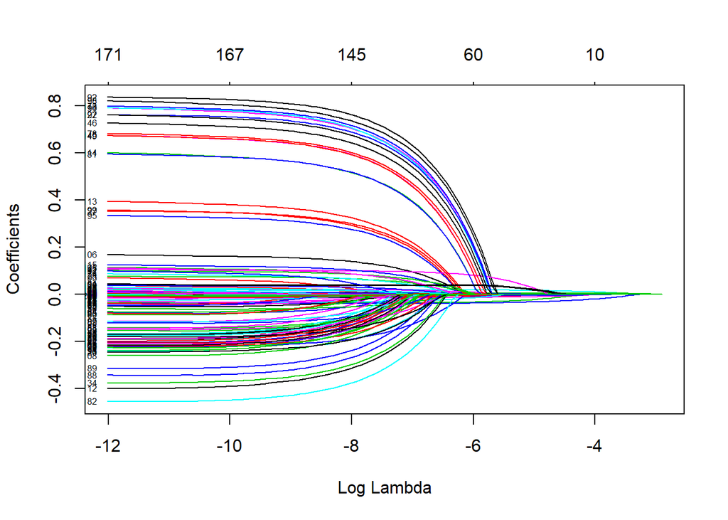

```r
plot(lassoModel,xvar='lambda',label=T) #Coefficients vs Log Lambda
```

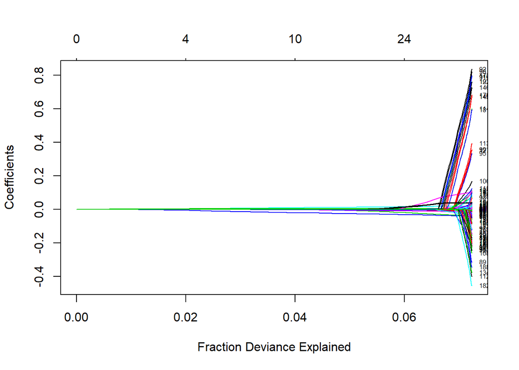

```r
plot(lassoModel,xvar='dev',label=T) #Coefficients vs fraction deviation
```

```r
cv.lasso = cv.glmnet(x,y,alpha=1) # 10-fold cross-validation
```

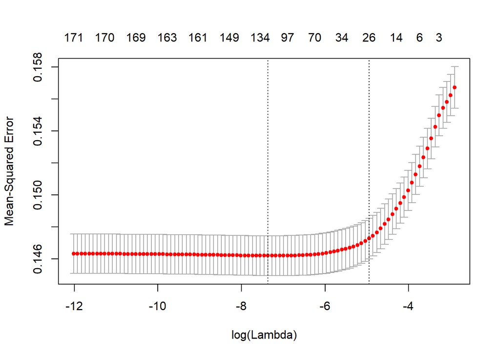

```r
plot(cv.lasso) #Mean-Squared Error vs log(Lambda)
```

```r
coef(cv.lasso)
```

```
## 201 x 1 sparse Matrix of class "dgCMatrix"
##                                     1
## (Intercept)              8.025321e-02
## (Intercept)              .
## X                        .
## Unnamed..0               .
## id                       .
## AP001                    .
## AP002                   -2.119801e-02
## AP003                   -3.156314e-02
## AP004                    1.633611e-02
## AP007                    3.614012e-03
## AP008                    1.855311e-03
## AP009                   -1.675198e-03
## TD001                    1.648999e-03
## TD002                    .
## TD005                    4.968481e-03
## TD006                    .
## TD009                    1.703098e-03
## TD010                    2.672561e-03
## TD013                    5.854862e-03
## TD014                    1.509535e-05
## TD015                    .
## TD022                    .
## TD023                    .
## TD024                    .
## TD025                    .
## TD026                    .
## TD027                    .
## TD028                    .
## TD029                    .
## TD044                    .
## TD051                    .
## TD054                    .
## TD061                    .
## CR004                    3.986709e-03
## CR005                    2.299929e-04
## CR009                    .
## CR012                    .
## CR015                   -9.671503e-03
```

[output cut: 148 more lines]

```
## MB007VOTO                .
## MB007WEB                 .
## MB007X6                  .
## MB007XIAOLAJIAO          .
## MB007XIAOMI              .
## MB007YEPEN               .
## MB007YTONE_L985          .
## MB007YU-FLY              .
## MB007YUFLY               .
## MB007ZTE                 .
## MB007ZUK                 .
## MB007ZUOKU               .
## TD048                    .
## TD055                    .
## TD062                    .
```

##### Combining the results of Feature selection models of Forward, Backward and Hybrid Stepwise regression and Lasso regression, we perform Logistic regression on the 31 highly statistically significant variables as follows.

### LOGISTIC REGRESSION

##### We use Logistic regression to create our final model as it is the most widespread technique, combining a high predictive capability with accuracy percentages not statistically significant, different from other more recent techniques

```r
logismodel = glm(loan_default~AP003+AP004+MB005+CR015+PA023+AP002+CD113+PA029+TD001+AP008+CD117+TD005+AP006+CD170+TD010+CR018+CD137+CD132+CD008+CD152+CR017+TD013+CR017+CD106+CD107+AP007+TD009+TD014+CR004+PA022+PA028+CD123,data=train,family='binomial')
summary(logismodel)
```

```
##
## Call:
## glm(formula = loan_default ~ AP003 + AP004 + MB005 + CR015 +
##     PA023 + AP002 + CD113 + PA029 + TD001 + AP008 + CD117 + TD005 +
##     AP006 + CD170 + TD010 + CR018 + CD137 + CD132 + CD008 + CD152 +
##     CR017 + TD013 + CR017 + CD106 + CD107 + AP007 + TD009 + TD014 +
##     CR004 + PA022 + PA028 + CD123, family = "binomial", data = train)
##
## Deviance Residuals:
##     Min       1Q   Median       3Q      Max
## -2.1247  -0.6938  -0.5441  -0.3334   3.5056
##
## Coefficients:
##               Estimate Std. Error z value Pr(>|z|)
## (Intercept) -2.600e+00  1.185e-01 -21.930  < 2e-16 ***
## AP003       -2.925e-01  1.051e-02 -27.821  < 2e-16 ***
## AP004        1.912e-01  7.452e-03  25.662  < 2e-16 ***
## MB005       -4.798e-02  3.457e-03 -13.880  < 2e-16 ***
## CR015       -1.178e-01  1.111e-02 -10.604  < 2e-16 ***
## PA023        2.363e-03  6.789e-04   3.480 0.000501 ***
## AP002       -2.852e-01  2.501e-02 -11.406  < 2e-16 ***
## CD113        3.573e-02  3.276e-03  10.905  < 2e-16 ***
## PA029        8.523e-04  3.219e-04   2.648 0.008109 **
## TD001        3.631e-02  8.205e-03   4.426 9.62e-06 ***
## AP008        3.443e-02  1.278e-02   2.695 0.007044 **
## CD117       -5.348e-03  1.020e-03  -5.242 1.59e-07 ***
## TD005        2.755e-02  8.148e-03   3.381 0.000722 ***
## AP006api    -4.717e-01  8.850e-02  -5.330 9.81e-08 ***
## AP006h5     -2.641e-01  2.818e-02  -9.373  < 2e-16 ***
## AP006ios    -2.803e-01  3.396e-02  -8.252  < 2e-16 ***
## CD170        4.671e-05  5.040e-06   9.268  < 2e-16 ***
## TD010        2.705e-02  1.257e-02   2.152 0.031390 *
## CR018        4.840e-02  9.646e-03   5.017 5.24e-07 ***
## CD137       -1.763e-03  4.430e-04  -3.978 6.94e-05 ***
## CD132        2.159e-03  6.083e-04   3.549 0.000387 ***
## CD008        7.507e-06  1.350e-06   5.562 2.66e-08 ***
## CD152       -4.146e-06  9.663e-07  -4.291 1.78e-05 ***
## CR017       -3.370e-02  1.000e-02  -3.369 0.000755 ***
## TD013        3.868e-02  5.892e-03   6.565 5.21e-11 ***
## CD106        8.785e-04  1.159e-03   0.758 0.448296
## CD107       -9.091e-03  2.192e-03  -4.148 3.36e-05 ***
## AP007        4.719e-02  1.273e-02   3.707 0.000209 ***
## TD009        1.385e-02  8.201e-03   1.688 0.091337 .
## TD014       -2.667e-04  1.092e-02  -0.024 0.980519
## CR004        6.700e-02  1.073e-02   6.247 4.19e-10 ***
## PA022        1.700e-03  6.605e-04   2.574 0.010043 *
## PA028        1.797e-04  3.237e-04   0.555 0.578867
## CD123       -8.083e-04  4.413e-04  -1.831 0.067039 .
## ---
## Signif. codes:  0 '***' 0.001 '**' 0.01 '*' 0.05 '.' 0.1 ' ' 1
##
## (Dispersion parameter for binomial family taken to be 1)
##
##     Null deviance: 55200  on 55999  degrees of freedom
## Residual deviance: 51056  on 55966  degrees of freedom
## AIC: 51124
##
## Number of Fisher Scoring iterations: 5
```

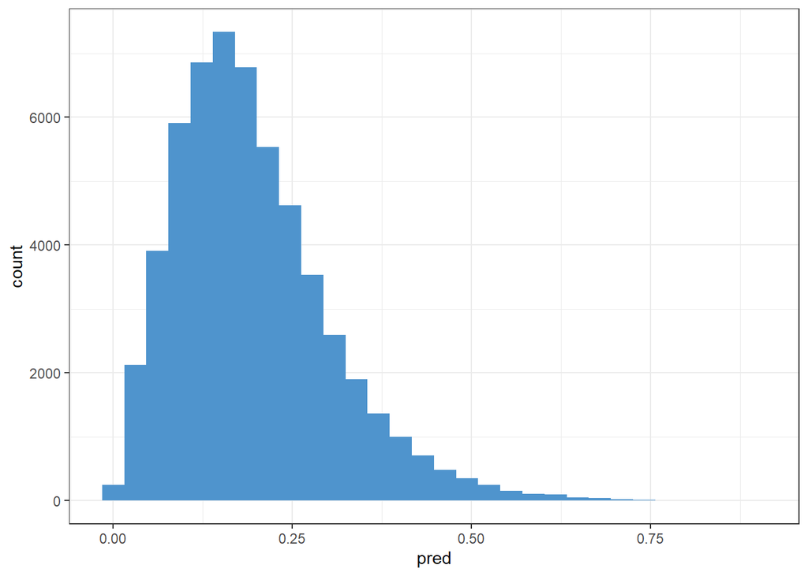

```r
#Assess Performance on train sample
#Use predict function and construct classification table
pred = predict(logismodel,type='response')
ggplot(data=data.frame(pred),aes(x=pred))+
  geom_histogram(fill='steelblue3')
```

```r
table(as.numeric(pred>0.5)) # how many predictions for loan default using a 0.5 cutoff
```

```
##
##     0     1
## 55171   829
```

```r
ct = table(train$loan_default,pred>0.5);ct # classification table
```

```
##
##     FALSE  TRUE
##   0 44695   406
##   1 10476   423
```

```r
accuracy = sum(ct[1,1],ct[2,2])/nrow(train); accuracy
```

```
## [1] 0.8056786
```

```r
specificity = ct[1,1]/sum(ct[1,1],ct[1,2]); specificity
```

```
## [1] 0.990998
```

```r
#How much better is the accuracy than just going with majority class
t = table(train$loan_default)
baseline = max(t[1],t[2])/nrow(train); baseline
```

```
## [1] 0.805375
```

```r
#Assess Performance (on test sample)
baseline = table(test$loan_default)[1]/nrow(test); baseline
```

```
##         0
## 0.8087917
```

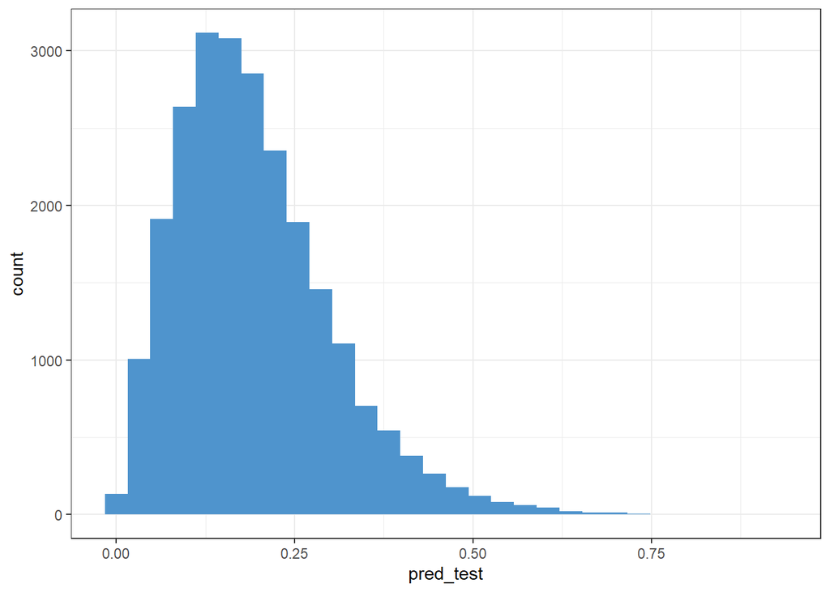

```r
#compute prediction quality on the test sample using logismodel
pred_test = predict(logismodel,newdata=test,type='response')
ggplot(data=data.frame(pred_test),aes(x=pred_test))+
  geom_histogram(fill='steelblue3')
```

```r
ct = table(test$loan_default,pred_test>0.5); ct
```

```
##
##     FALSE  TRUE
##   0 19233   178
##   1  4422   167
```

```r
accuracy = sum(ct[1,1],ct[2,2])/nrow(test); accuracy
```

```
## [1] 0.8083333
```

```r
specificity = ct[1,1]/sum(ct[1,1],ct[1,2]); specificity
```

```
## [1] 0.9908299
```

##### The model’s accuracy on both Train and Test data is approximately equal to 80% which shows that there is neither overfitting nor underfitting happened with our model which is good.

```r
ROCRpred = prediction(pred_test,test$loan_default)
as.numeric(performance(ROCRpred,"auc")@y.values) # auc measure
```

```
## [1] 0.7023915
```

```r
test <- cbind(test, pred_test)
```

#### Gains Table

##### In the Gains table, Test data set is scored and sorted from high to low probability of default and put into equal segments

```r
gain.table <- with(test, gains(actual=loan_default, predicted=pred_test, optimal=TRUE, percents=TRUE))
gain.table
```

```
## Depth                            Cume   Cume Pct                 Optimal Optimal     Mean
##  of           Cume     Resp      Resp   of Total    Lift   Cume    Lift    Cume     Model
## File     N      N      Rate      Rate      Resp    Index   Lift   Index    Lift     Score
## ------------------------------------------------------------------------------------------
##   10  2400   2400     41.29%    41.29%     21.6%     216    216     523     523     42.13%
##   20  2400   4800     31.37%    36.33%     38.0%     164    190     477     500     30.27%
##   30  2400   7200     27.00%    33.22%     52.1%     141    174       0     333     25.34%
##   40  2400   9600     22.79%    30.61%     64.0%     119    160       0     250     21.83%
##   50  2400  12000     18.25%    28.14%     73.6%      95    147       0     200     18.95%
##   60  2400  14400     15.21%    25.99%     81.5%      80    136       0     167     16.38%
##   70  2400  16800     13.29%    24.17%     88.5%      70    126       0     143     13.89%
##   80  2400  19200     10.92%    22.52%     94.2%      57    118       0     125     11.44%
##   90  2400  21600      7.71%    20.87%     98.2%      40    109       0     111      8.68%
##  100  2400  24000      3.38%    19.12%    100.0%      18    100       0     100      4.63%
```

#### Construct ROC plot

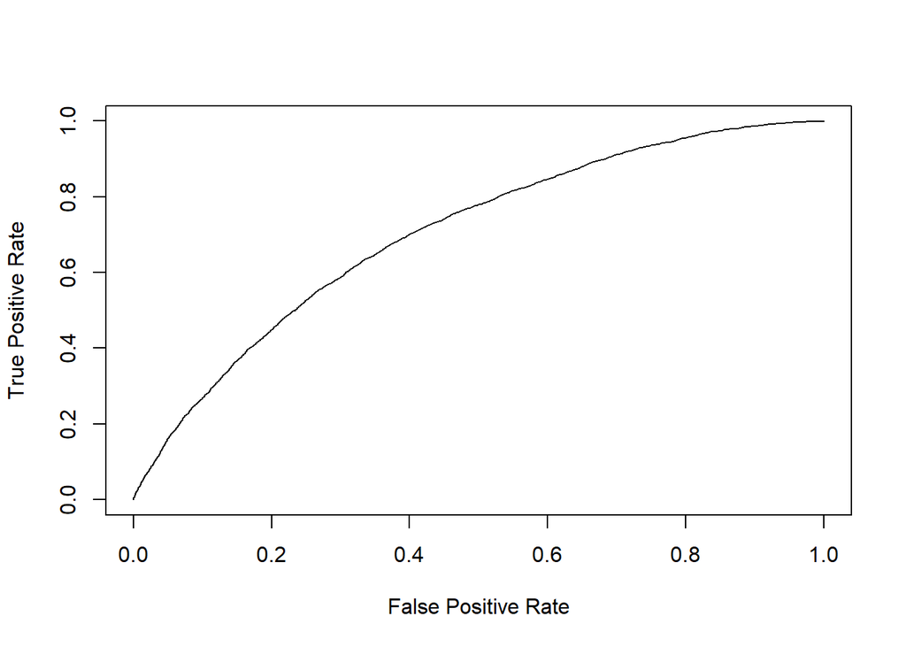

```r
ROCRperf = performance(ROCRpred,"tpr","fpr")
plot(ROCRperf,xlab="False Positive Rate",ylab="True Positive Rate") # basic plot with labeled axes
```